# Building a decision tree model of antenatal HIV transmission

Foundation Course Exercise 2

Jack Williams & Nichola Naylor

14 April 2021

## Overview

Imagine that you have been asked to advise local decision-makers on the cost-effectiveness of antenatal HIV testing (i.e. testing pregnant women for the HIV virus). You undertake a Medline search to identify published economic evaluations - but find nothing to help you in your analysis. You quickly realise that you will have to undertake a decision analysis of your own using data from available data sources.

### Data

From a Medline search you identify publications that provide you with the following information:

- If a woman has HIV and her infection remains undetected during pregnancy, the probability that she will transmit the infection to her child is 26%.
- If a woman’s infection is known during pregnancy, however, it is possible to use risk-reduction interventions such as caesarean section, zidovudine antiretroviral therapy and bottle-feeding. These interventions cost £800 more than a normal delivery and reduce the probability of transmission to the child to 7%, but only 95% of infected women accept the interventions.
- Discussion with midwifery staff indicates that offering the test to women could be achieved at negligible additional cost, but your pathology labs suggest that each blood test will cost £10; they also indicate that the tests are 100% accurate (i.e. there are no false negatives or false positives).
- A published paper suggests that the prevalence of undetected HIV in the antenatal population in your area is 5%.

### Assumptions

Discussions with professional staff indicate that the following assumptions can be justified:

- No women will select to terminate on discovering she has HIV infection.
- All women who are tested positive will be offered risk-reduction interventions.

### Decision Tree Figure

To help visualise the decision tree model structure, we have provided the decision tree and conditional probabilities for each branch below:

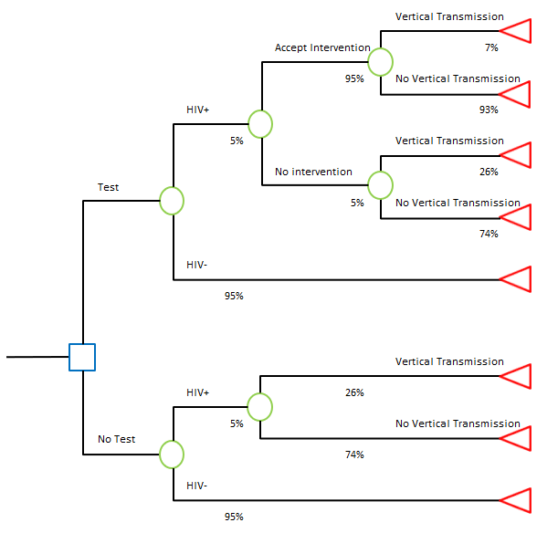

## Tasks

```r
testing.results
```

```
##     costs     cases
## 48.000000  0.003975
```

What do your results show? You should have an estimated **£5318.56** per HIV-infected child avoided. If not, then make sure that you have used the correct parameters in calculating the incremental results.

Now that we have finished the practical component of the exercise, consider some of the other aspects of this analysis:

6. What are likely to be the key sensitivity analyses to undertake?
7. What are the weaknesses of the analysis?